# Risk Factor Analysis

## Outcome Variable

**Outcome Variable:** stunted

## Predictor Variables

**Intervention Variable:** impsan

**Adjustment Set:**

- arm
- sex
- W_mage
- meducyrs
- feducyrs
- hhwealth_quart
- hfoodsec
- W_mhtcm
- W_nrooms
- W_nchldlt5
- W_parity
- impfloor
- safeh20
- delta_W_mage
- delta_meducyrs
- delta_feducyrs
- delta_hhwealth_quart
- delta_hfoodsec
- delta_W_mhtcm
- delta_W_nrooms
- delta_W_nchldlt5
- delta_W_parity
- delta_impfloor
- delta_safeh20

## Stratifying Variables

The analysis was stratified on these variable(s):

- agecat
- studyid
- country

## Data Summary

| agecat | studyid | country | impsan | stunted | n_cell | n |
| --- | --- | --- | --- | --- | --- | --- |
| Birth | ki0047075b-MAL-ED | BANGLADESH | 1 | 0 | 164 | 234 |
| Birth | ki0047075b-MAL-ED | BANGLADESH | 1 | 1 | 33 | 234 |
| Birth | ki0047075b-MAL-ED | BANGLADESH | 0 | 0 | 32 | 234 |
| Birth | ki0047075b-MAL-ED | BANGLADESH | 0 | 1 | 5 | 234 |
| Birth | ki0047075b-MAL-ED | BRAZIL | 1 | 0 | 153 | 174 |
| Birth | ki0047075b-MAL-ED | BRAZIL | 1 | 1 | 17 | 174 |
| Birth | ki0047075b-MAL-ED | BRAZIL | 0 | 0 | 4 | 174 |
| Birth | ki0047075b-MAL-ED | BRAZIL | 0 | 1 | 0 | 174 |
| Birth | ki0047075b-MAL-ED | INDIA | 1 | 0 | 76 | 190 |
| Birth | ki0047075b-MAL-ED | INDIA | 1 | 1 | 16 | 190 |
| Birth | ki0047075b-MAL-ED | INDIA | 0 | 0 | 85 | 190 |
| Birth | ki0047075b-MAL-ED | INDIA | 0 | 1 | 13 | 190 |
| Birth | ki0047075b-MAL-ED | NEPAL | 1 | 0 | 152 | 171 |
| Birth | ki0047075b-MAL-ED | NEPAL | 1 | 1 | 18 | 171 |
| Birth | ki0047075b-MAL-ED | NEPAL | 0 | 0 | 1 | 171 |
| Birth | ki0047075b-MAL-ED | NEPAL | 0 | 1 | 0 | 171 |
| Birth | ki0047075b-MAL-ED | PERU | 1 | 0 | 54 | 250 |
| Birth | ki0047075b-MAL-ED | PERU | 1 | 1 | 8 | 250 |
| Birth | ki0047075b-MAL-ED | PERU | 0 | 0 | 167 | 250 |
| Birth | ki0047075b-MAL-ED | PERU | 0 | 1 | 21 | 250 |
| Birth | ki0047075b-MAL-ED | SOUTH AFRICA | 1 | 0 | 2 | 213 |
| Birth | ki0047075b-MAL-ED | SOUTH AFRICA | 1 | 1 | 0 | 213 |
| Birth | ki0047075b-MAL-ED | SOUTH AFRICA | 0 | 0 | 191 | 213 |
| Birth | ki0047075b-MAL-ED | SOUTH AFRICA | 0 | 1 | 20 | 213 |
| Birth | ki0047075b-MAL-ED | TANZANIA, UNITED REPUBLIC OF | 1 | 0 | 0 | 113 |
| Birth | ki0047075b-MAL-ED | TANZANIA, UNITED REPUBLIC OF | 1 | 1 | 0 | 113 |
| Birth | ki0047075b-MAL-ED | TANZANIA, UNITED REPUBLIC OF | 0 | 0 | 97 | 113 |
| Birth | ki0047075b-MAL-ED | TANZANIA, UNITED REPUBLIC OF | 0 | 1 | 16 | 113 |
| Birth | ki1017093-NIH-Birth | BANGLADESH | 1 | 0 | 9 | 28 |
| Birth | ki1017093-NIH-Birth | BANGLADESH | 1 | 1 | 0 | 28 |

[output cut: 166 more lines]

The following strata were considered:

- agecat: 24 months, studyid: ki0047075b-MAL-ED, country: BANGLADESH
- agecat: 24 months, studyid: ki0047075b-MAL-ED, country: BRAZIL
- agecat: 24 months, studyid: ki0047075b-MAL-ED, country: INDIA
- agecat: 24 months, studyid: ki0047075b-MAL-ED, country: NEPAL
- agecat: 24 months, studyid: ki0047075b-MAL-ED, country: PERU
- agecat: 24 months, studyid: ki0047075b-MAL-ED, country: SOUTH AFRICA
- agecat: 24 months, studyid: ki0047075b-MAL-ED, country: TANZANIA, UNITED REPUBLIC OF
- agecat: 24 months, studyid: ki1017093-NIH-Birth, country: BANGLADESH
- agecat: 24 months, studyid: ki1017093b-PROVIDE, country: BANGLADESH
- agecat: 24 months, studyid: ki1017093c-NIH-Crypto, country: BANGLADESH
- agecat: 24 months, studyid: ki1114097-CONTENT, country: PERU
- agecat: 24 months, studyid: ki1135781-COHORTS, country: GUATEMALA
- agecat: 24 months, studyid: ki1135781-COHORTS, country: INDIA
- agecat: 24 months, studyid: ki1135781-COHORTS, country: PHILIPPINES
- agecat: 24 months, studyid: ki1148112-LCNI-5, country: MALAWI
- agecat: 24 months, studyid: kiGH5241-JiVitA-3, country: BANGLADESH
- agecat: 24 months, studyid: kiGH5241-JiVitA-4, country: BANGLADESH
- agecat: 6 months, studyid: ki0047075b-MAL-ED, country: BANGLADESH
- agecat: 6 months, studyid: ki0047075b-MAL-ED, country: BRAZIL
- agecat: 6 months, studyid: ki0047075b-MAL-ED, country: INDIA
- agecat: 6 months, studyid: ki0047075b-MAL-ED, country: NEPAL
- agecat: 6 months, studyid: ki0047075b-MAL-ED, country: PERU
- agecat: 6 months, studyid: ki0047075b-MAL-ED, country: SOUTH AFRICA
- agecat: 6 months, studyid: ki0047075b-MAL-ED, country: TANZANIA, UNITED REPUBLIC OF
- agecat: 6 months, studyid: ki1017093-NIH-Birth, country: BANGLADESH
- agecat: 6 months, studyid: ki1017093b-PROVIDE, country: BANGLADESH
- agecat: 6 months, studyid: ki1017093c-NIH-Crypto, country: BANGLADESH
- agecat: 6 months, studyid: ki1114097-CONTENT, country: PERU
- agecat: 6 months, studyid: ki1135781-COHORTS, country: GUATEMALA
- agecat: 6 months, studyid: ki1135781-COHORTS, country: INDIA
- agecat: 6 months, studyid: ki1135781-COHORTS, country: PHILIPPINES
- agecat: 6 months, studyid: ki1148112-LCNI-5, country: MALAWI
- agecat: 6 months, studyid: kiGH5241-JiVitA-3, country: BANGLADESH
- agecat: 6 months, studyid: kiGH5241-JiVitA-4, country: BANGLADESH
- agecat: Birth, studyid: ki0047075b-MAL-ED, country: BANGLADESH
- agecat: Birth, studyid: ki0047075b-MAL-ED, country: BRAZIL
- agecat: Birth, studyid: ki0047075b-MAL-ED, country: INDIA
- agecat: Birth, studyid: ki0047075b-MAL-ED, country: NEPAL
- agecat: Birth, studyid: ki0047075b-MAL-ED, country: PERU
- agecat: Birth, studyid: ki0047075b-MAL-ED, country: SOUTH AFRICA
- agecat: Birth, studyid: ki0047075b-MAL-ED, country: TANZANIA, UNITED REPUBLIC OF
- agecat: Birth, studyid: ki1017093-NIH-Birth, country: BANGLADESH
- agecat: Birth, studyid: ki1017093c-NIH-Crypto, country: BANGLADESH
- agecat: Birth, studyid: ki1114097-CONTENT, country: PERU
- agecat: Birth, studyid: ki1135781-COHORTS, country: GUATEMALA
- agecat: Birth, studyid: ki1135781-COHORTS, country: INDIA
- agecat: Birth, studyid: ki1135781-COHORTS, country: PHILIPPINES
- agecat: Birth, studyid: kiGH5241-JiVitA-3, country: BANGLADESH
- agecat: Birth, studyid: kiGH5241-JiVitA-4, country: BANGLADESH

### Dropped Strata

Some strata were dropped due to rare outcomes:

- agecat: Birth, studyid: ki0047075b-MAL-ED, country: BRAZIL
- agecat: Birth, studyid: ki0047075b-MAL-ED, country: NEPAL
- agecat: Birth, studyid: ki0047075b-MAL-ED, country: SOUTH AFRICA
- agecat: Birth, studyid: ki0047075b-MAL-ED, country: TANZANIA, UNITED REPUBLIC OF
- agecat: Birth, studyid: ki1017093-NIH-Birth, country: BANGLADESH
- agecat: Birth, studyid: ki1017093c-NIH-Crypto, country: BANGLADESH
- agecat: Birth, studyid: ki1114097-CONTENT, country: PERU
- agecat: Birth, studyid: ki1135781-COHORTS, country: GUATEMALA
- agecat: Birth, studyid: ki1135781-COHORTS, country: PHILIPPINES
- agecat: 6 months, studyid: ki0047075b-MAL-ED, country: BRAZIL
- agecat: 6 months, studyid: ki0047075b-MAL-ED, country: NEPAL
- agecat: 6 months, studyid: ki0047075b-MAL-ED, country: SOUTH AFRICA
- agecat: 6 months, studyid: ki0047075b-MAL-ED, country: TANZANIA, UNITED REPUBLIC OF
- agecat: 6 months, studyid: ki1114097-CONTENT, country: PERU
- agecat: 6 months, studyid: ki1148112-LCNI-5, country: MALAWI
- agecat: 24 months, studyid: ki0047075b-MAL-ED, country: BRAZIL
- agecat: 24 months, studyid: ki0047075b-MAL-ED, country: NEPAL
- agecat: 24 months, studyid: ki0047075b-MAL-ED, country: SOUTH AFRICA
- agecat: 24 months, studyid: ki0047075b-MAL-ED, country: TANZANIA, UNITED REPUBLIC OF
- agecat: 24 months, studyid: ki1114097-CONTENT, country: PERU
- agecat: 24 months, studyid: ki1148112-LCNI-5, country: MALAWI

## Methods Detail

We’re interested in the causal parameters $E[Y_a]$ for all values of $a \in \mathcal{A}$. These parameters represent the mean outcome if, possibly contrary to fact, we intervened to set all units to have $A=a$. Under the randomization and positivity assumptions, these are identified by the statistical parameters $\psi_a=E_W[E_{Y|A,W}(Y|A=a,W)]$. In addition, we’re interested in the mean of $Y$, $E[Y]$ under no intervention (the observed mean). We will estimate these parameters by using SuperLearner to fit the relevant likelihood factors – $E_{Y|A,W}(Y|A=a,W)$ and $p(A=a|W)$, and then updating our likelihood fit using a joint TMLE.

For unadjusted analyses ($W=\{\}$), initial likelihoods were estimated using Lrnr_glm to estimate the simple $E(Y|A)$ and Lrnr_mean to estimate $p(A)$. For adjusted analyses, a small library containing Lrnr_glmnet, Lrnr_xgboost, and Lrnr_mean was used.

Having estimated these parameters, we will then use the delta method to estimate relative risks and attributable risks relative to a prespecified baseline level of $A$.

# Results Detail

## Results Plots

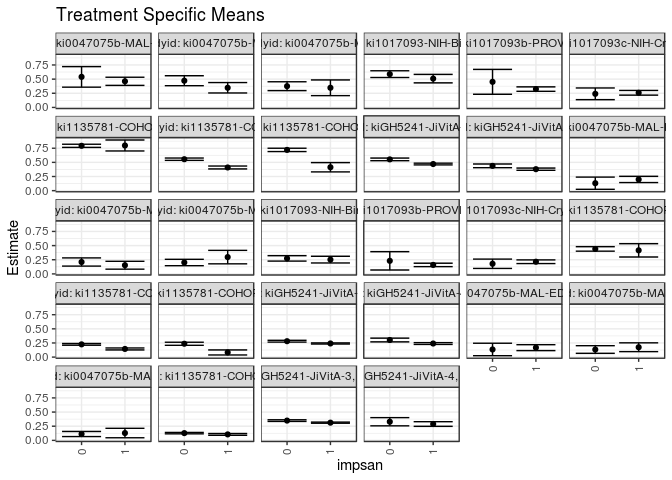

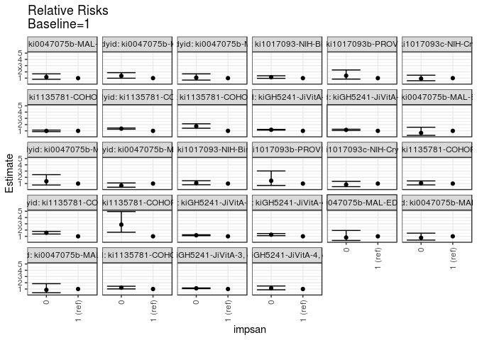

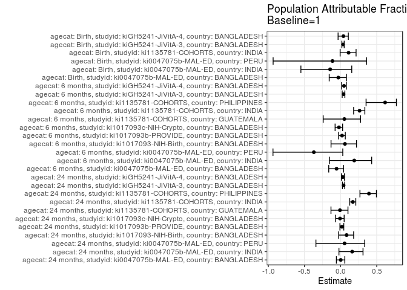

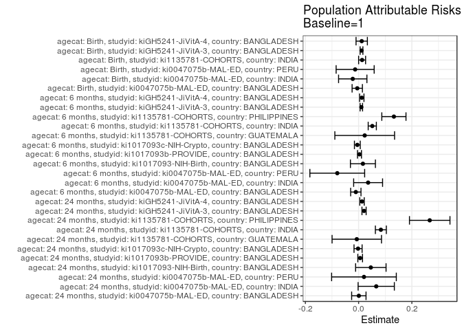

## Results Table

### Parameter: TSM

| agecat | studyid | country | intervention_level | baseline_level | estimate | ci_lower | ci_upper |
| --- | --- | --- | --- | --- | --- | --- | --- |
| Birth | ki0047075b-MAL-ED | BANGLADESH | 1 | NA | 0.1675127 | 0.1152541 | 0.2197713 |
| Birth | ki0047075b-MAL-ED | BANGLADESH | 0 | NA | 0.1351351 | 0.0247437 | 0.2455266 |
| Birth | ki0047075b-MAL-ED | INDIA | 1 | NA | 0.1747181 | 0.0967680 | 0.2526682 |
| Birth | ki0047075b-MAL-ED | INDIA | 0 | NA | 0.1341214 | 0.0667518 | 0.2014910 |
| Birth | ki0047075b-MAL-ED | PERU | 1 | NA | 0.1290323 | 0.0454195 | 0.2126451 |
| Birth | ki0047075b-MAL-ED | PERU | 0 | NA | 0.1117021 | 0.0665842 | 0.1568201 |
| Birth | ki1135781-COHORTS | INDIA | 1 | NA | 0.1052105 | 0.0898016 | 0.1206194 |
| Birth | ki1135781-COHORTS | INDIA | 0 | NA | 0.1276700 | 0.1155206 | 0.1398194 |
| Birth | kiGH5241-JiVitA-3 | BANGLADESH | 1 | NA | 0.3125058 | 0.3031890 | 0.3218227 |
| Birth | kiGH5241-JiVitA-3 | BANGLADESH | 0 | NA | 0.3492517 | 0.3349634 | 0.3635399 |
| Birth | kiGH5241-JiVitA-4 | BANGLADESH | 1 | NA | 0.2888738 | 0.2478071 | 0.3299406 |
| Birth | kiGH5241-JiVitA-4 | BANGLADESH | 0 | NA | 0.3290853 | 0.2565813 | 0.4015893 |
| 6 months | ki0047075b-MAL-ED | BANGLADESH | 1 | NA | 0.1980198 | 0.1429498 | 0.2530898 |
| 6 months | ki0047075b-MAL-ED | BANGLADESH | 0 | NA | 0.1315789 | 0.0238775 | 0.2392803 |
| 6 months | ki0047075b-MAL-ED | INDIA | 1 | NA | 0.1531776 | 0.0836140 | 0.2227411 |
| 6 months | ki0047075b-MAL-ED | INDIA | 0 | NA | 0.2098477 | 0.1372516 | 0.2824437 |
| 6 months | ki0047075b-MAL-ED | PERU | 1 | NA | 0.2969562 | 0.1779759 | 0.4159365 |
| 6 months | ki0047075b-MAL-ED | PERU | 0 | NA | 0.2011766 | 0.1445890 | 0.2577643 |
| 6 months | ki1017093-NIH-Birth | BANGLADESH | 1 | NA | 0.2520420 | 0.1927222 | 0.3113617 |
| 6 months | ki1017093-NIH-Birth | BANGLADESH | 0 | NA | 0.2738953 | 0.2259261 | 0.3218644 |
| 6 months | ki1017093b-PROVIDE | BANGLADESH | 1 | NA | 0.1585586 | 0.1281439 | 0.1889732 |
| 6 months | ki1017093b-PROVIDE | BANGLADESH | 0 | NA | 0.2307692 | 0.0686805 | 0.3928579 |
| 6 months | ki1017093c-NIH-Crypto | BANGLADESH | 1 | NA | 0.2150382 | 0.1825619 | 0.2475145 |
| 6 months | ki1017093c-NIH-Crypto | BANGLADESH | 0 | NA | 0.1790072 | 0.0964537 | 0.2615607 |
| 6 months | ki1135781-COHORTS | GUATEMALA | 1 | NA | 0.4163659 | 0.2984898 | 0.5342419 |
| 6 months | ki1135781-COHORTS | GUATEMALA | 0 | NA | 0.4411496 | 0.4011729 | 0.4811264 |
| 6 months | ki1135781-COHORTS | INDIA | 1 | NA | 0.1444482 | 0.1270618 | 0.1618346 |
| 6 months | ki1135781-COHORTS | INDIA | 0 | NA | 0.2254410 | 0.2106854 | 0.2401965 |
| 6 months | ki1135781-COHORTS | PHILIPPINES | 1 | NA | 0.0826182 | 0.0382353 | 0.1270011 |
| 6 months | ki1135781-COHORTS | PHILIPPINES | 0 | NA | 0.2362321 | 0.2090723 | 0.2633920 |
| 6 months | kiGH5241-JiVitA-3 | BANGLADESH | 1 | NA | 0.2412318 | 0.2318499 | 0.2506137 |
| 6 months | kiGH5241-JiVitA-3 | BANGLADESH | 0 | NA | 0.2815270 | 0.2657555 | 0.2972985 |
| 6 months | kiGH5241-JiVitA-4 | BANGLADESH | 1 | NA | 0.2403397 | 0.2243123 | 0.2563670 |
| 6 months | kiGH5241-JiVitA-4 | BANGLADESH | 0 | NA | 0.3025652 | 0.2696931 | 0.3354374 |
| 24 months | ki0047075b-MAL-ED | BANGLADESH | 1 | NA | 0.4614534 | 0.3892019 | 0.5337048 |
| 24 months | ki0047075b-MAL-ED | BANGLADESH | 0 | NA | 0.5398483 | 0.3582742 | 0.7214225 |
| 24 months | ki0047075b-MAL-ED | INDIA | 1 | NA | 0.3471897 | 0.2554564 | 0.4389229 |
| 24 months | ki0047075b-MAL-ED | INDIA | 0 | NA | 0.4722039 | 0.3842312 | 0.5601766 |
| 24 months | ki0047075b-MAL-ED | PERU | 1 | NA | 0.3472680 | 0.2086463 | 0.4858897 |
| 24 months | ki0047075b-MAL-ED | PERU | 0 | NA | 0.3752807 | 0.2971137 | 0.4534478 |
| 24 months | ki1017093-NIH-Birth | BANGLADESH | 1 | NA | 0.5088993 | 0.4340979 | 0.5837008 |
| 24 months | ki1017093-NIH-Birth | BANGLADESH | 0 | NA | 0.5881426 | 0.5286303 | 0.6476549 |
| 24 months | ki1017093b-PROVIDE | BANGLADESH | 1 | NA | 0.3240238 | 0.2849187 | 0.3631289 |
| 24 months | ki1017093b-PROVIDE | BANGLADESH | 0 | NA | 0.4522846 | 0.2325009 | 0.6720683 |
| 24 months | ki1017093c-NIH-Crypto | BANGLADESH | 1 | NA | 0.2585901 | 0.2172886 | 0.2998916 |
| 24 months | ki1017093c-NIH-Crypto | BANGLADESH | 0 | NA | 0.2404485 | 0.1372012 | 0.3436958 |
| 24 months | ki1135781-COHORTS | GUATEMALA | 1 | NA | 0.7981899 | 0.7012077 | 0.8951722 |
| 24 months | ki1135781-COHORTS | GUATEMALA | 0 | NA | 0.7923956 | 0.7644596 | 0.8203316 |
| 24 months | ki1135781-COHORTS | INDIA | 1 | NA | 0.4095184 | 0.3839733 | 0.4350635 |
| 24 months | ki1135781-COHORTS | INDIA | 0 | NA | 0.5556043 | 0.5350437 | 0.5761650 |
| 24 months | ki1135781-COHORTS | PHILIPPINES | 1 | NA | 0.4137101 | 0.3317428 | 0.4956774 |
| 24 months | ki1135781-COHORTS | PHILIPPINES | 0 | NA | 0.7201135 | 0.6903811 | 0.7498459 |
| 24 months | kiGH5241-JiVitA-3 | BANGLADESH | 1 | NA | 0.4704318 | 0.4551815 | 0.4856821 |
| 24 months | kiGH5241-JiVitA-3 | BANGLADESH | 0 | NA | 0.5526032 | 0.5293576 | 0.5758488 |
| 24 months | kiGH5241-JiVitA-4 | BANGLADESH | 1 | NA | 0.3795047 | 0.3598102 | 0.3991991 |
| 24 months | kiGH5241-JiVitA-4 | BANGLADESH | 0 | NA | 0.4382829 | 0.4055609 | 0.4710049 |

### Parameter: E(Y)

| agecat | studyid | country | intervention_level | baseline_level | estimate | ci_lower | ci_upper |
| --- | --- | --- | --- | --- | --- | --- | --- |
| Birth | ki0047075b-MAL-ED | BANGLADESH | NA | NA | 0.1623932 | 0.1150373 | 0.2097491 |
| Birth | ki0047075b-MAL-ED | INDIA | NA | NA | 0.1526316 | 0.1013601 | 0.2039030 |
| Birth | ki0047075b-MAL-ED | PERU | NA | NA | 0.1160000 | 0.0762256 | 0.1557744 |
| Birth | ki1135781-COHORTS | INDIA | NA | NA | 0.1182998 | 0.1091394 | 0.1274602 |
| Birth | kiGH5241-JiVitA-3 | BANGLADESH | NA | NA | 0.3233463 | 0.3156839 | 0.3310086 |
| Birth | kiGH5241-JiVitA-4 | BANGLADESH | NA | NA | 0.3004866 | 0.2649179 | 0.3360553 |
| 6 months | ki0047075b-MAL-ED | BANGLADESH | NA | NA | 0.1875000 | 0.1380164 | 0.2369836 |
| 6 months | ki0047075b-MAL-ED | INDIA | NA | NA | 0.1888412 | 0.1384789 | 0.2392035 |
| 6 months | ki0047075b-MAL-ED | PERU | NA | NA | 0.2167300 | 0.1668401 | 0.2666199 |
| 6 months | ki1017093-NIH-Birth | BANGLADESH | NA | NA | 0.2681564 | 0.2306532 | 0.3056597 |
| 6 months | ki1017093b-PROVIDE | BANGLADESH | NA | NA | 0.1617900 | 0.1318200 | 0.1917600 |
| 6 months | ki1017093c-NIH-Crypto | BANGLADESH | NA | NA | 0.2102273 | 0.1801065 | 0.2403480 |
| 6 months | ki1135781-COHORTS | GUATEMALA | NA | NA | 0.4392097 | 0.4012606 | 0.4771588 |
| 6 months | ki1135781-COHORTS | INDIA | NA | NA | 0.1957353 | 0.1847045 | 0.2067660 |
| 6 months | ki1135781-COHORTS | PHILIPPINES | NA | NA | 0.2151431 | 0.1906585 | 0.2396277 |
| 6 months | kiGH5241-JiVitA-3 | BANGLADESH | NA | NA | 0.2514286 | 0.2432891 | 0.2595681 |
| 6 months | kiGH5241-JiVitA-4 | BANGLADESH | NA | NA | 0.2522280 | 0.2381653 | 0.2662906 |
| 24 months | ki0047075b-MAL-ED | BANGLADESH | NA | NA | 0.4622642 | 0.3949918 | 0.5295365 |
| 24 months | ki0047075b-MAL-ED | INDIA | NA | NA | 0.4133333 | 0.3488467 | 0.4778200 |
| 24 months | ki0047075b-MAL-ED | PERU | NA | NA | 0.3673469 | 0.2996839 | 0.4350100 |
| 24 months | ki1017093-NIH-Birth | BANGLADESH | NA | NA | 0.5547786 | 0.5076945 | 0.6018626 |
| 24 months | ki1017093b-PROVIDE | BANGLADESH | NA | NA | 0.3298611 | 0.2914318 | 0.3682904 |
| 24 months | ki1017093c-NIH-Crypto | BANGLADESH | NA | NA | 0.2564612 | 0.2182616 | 0.2946608 |
| 24 months | ki1135781-COHORTS | GUATEMALA | NA | NA | 0.7912946 | 0.7646707 | 0.8179186 |
| 24 months | ki1135781-COHORTS | INDIA | NA | NA | 0.4930741 | 0.4770789 | 0.5090692 |
| 24 months | ki1135781-COHORTS | PHILIPPINES | NA | NA | 0.6808081 | 0.6517553 | 0.7098609 |
| 24 months | kiGH5241-JiVitA-3 | BANGLADESH | NA | NA | 0.4908374 | 0.4777103 | 0.5039644 |
| 24 months | kiGH5241-JiVitA-4 | BANGLADESH | NA | NA | 0.3922477 | 0.3752571 | 0.4092384 |

### Parameter: RR

| agecat | studyid | country | intervention_level | baseline_level | estimate | ci_lower | ci_upper |
| --- | --- | --- | --- | --- | --- | --- | --- |
| Birth | ki0047075b-MAL-ED | BANGLADESH | 1 | 1 | 1.0000000 | 1.0000000 | 1.000000 |
| Birth | ki0047075b-MAL-ED | BANGLADESH | 0 | 1 | 0.8067158 | 0.3364777 | 1.934126 |
| Birth | ki0047075b-MAL-ED | INDIA | 1 | 1 | 1.0000000 | 1.0000000 | 1.000000 |
| Birth | ki0047075b-MAL-ED | INDIA | 0 | 1 | 0.7676447 | 0.3926217 | 1.500881 |
| Birth | ki0047075b-MAL-ED | PERU | 1 | 1 | 1.0000000 | 1.0000000 | 1.000000 |
| Birth | ki0047075b-MAL-ED | PERU | 0 | 1 | 0.8656915 | 0.4034095 | 1.857719 |
| Birth | ki1135781-COHORTS | INDIA | 1 | 1 | 1.0000000 | 1.0000000 | 1.000000 |
| Birth | ki1135781-COHORTS | INDIA | 0 | 1 | 1.2134717 | 1.0192218 | 1.444743 |
| Birth | kiGH5241-JiVitA-3 | BANGLADESH | 1 | 1 | 1.0000000 | 1.0000000 | 1.000000 |
| Birth | kiGH5241-JiVitA-3 | BANGLADESH | 0 | 1 | 1.1175844 | 1.0644303 | 1.173393 |
| Birth | kiGH5241-JiVitA-4 | BANGLADESH | 1 | 1 | 1.0000000 | 1.0000000 | 1.000000 |
| Birth | kiGH5241-JiVitA-4 | BANGLADESH | 0 | 1 | 1.1392008 | 0.8759702 | 1.481532 |
| 6 months | ki0047075b-MAL-ED | BANGLADESH | 1 | 1 | 1.0000000 | 1.0000000 | 1.000000 |
| 6 months | ki0047075b-MAL-ED | BANGLADESH | 0 | 1 | 0.6644737 | 0.2799219 | 1.577316 |
| 6 months | ki0047075b-MAL-ED | INDIA | 1 | 1 | 1.0000000 | 1.0000000 | 1.000000 |
| 6 months | ki0047075b-MAL-ED | INDIA | 0 | 1 | 1.3699635 | 0.7739199 | 2.425057 |
| 6 months | ki0047075b-MAL-ED | PERU | 1 | 1 | 1.0000000 | 1.0000000 | 1.000000 |
| 6 months | ki0047075b-MAL-ED | PERU | 0 | 1 | 0.6774623 | 0.4162921 | 1.102484 |
| 6 months | ki1017093-NIH-Birth | BANGLADESH | 1 | 1 | 1.0000000 | 1.0000000 | 1.000000 |
| 6 months | ki1017093-NIH-Birth | BANGLADESH | 0 | 1 | 1.0867051 | 0.8116907 | 1.454899 |
| 6 months | ki1017093b-PROVIDE | BANGLADESH | 1 | 1 | 1.0000000 | 1.0000000 | 1.000000 |
| 6 months | ki1017093b-PROVIDE | BANGLADESH | 0 | 1 | 1.4554196 | 0.7027093 | 3.014399 |
| 6 months | ki1017093c-NIH-Crypto | BANGLADESH | 1 | 1 | 1.0000000 | 1.0000000 | 1.000000 |
| 6 months | ki1017093c-NIH-Crypto | BANGLADESH | 0 | 1 | 0.8324438 | 0.5127102 | 1.351568 |
| 6 months | ki1135781-COHORTS | GUATEMALA | 1 | 1 | 1.0000000 | 1.0000000 | 1.000000 |
| 6 months | ki1135781-COHORTS | GUATEMALA | 0 | 1 | 1.0595240 | 0.7892928 | 1.422275 |
| 6 months | ki1135781-COHORTS | INDIA | 1 | 1 | 1.0000000 | 1.0000000 | 1.000000 |
| 6 months | ki1135781-COHORTS | INDIA | 0 | 1 | 1.5607048 | 1.3618449 | 1.788603 |
| 6 months | ki1135781-COHORTS | PHILIPPINES | 1 | 1 | 1.0000000 | 1.0000000 | 1.000000 |
| 6 months | ki1135781-COHORTS | PHILIPPINES | 0 | 1 | 2.8593222 | 1.6504473 | 4.953641 |
| 6 months | kiGH5241-JiVitA-3 | BANGLADESH | 1 | 1 | 1.0000000 | 1.0000000 | 1.000000 |
| 6 months | kiGH5241-JiVitA-3 | BANGLADESH | 0 | 1 | 1.1670395 | 1.0949620 | 1.243862 |
| 6 months | kiGH5241-JiVitA-4 | BANGLADESH | 1 | 1 | 1.0000000 | 1.0000000 | 1.000000 |
| 6 months | kiGH5241-JiVitA-4 | BANGLADESH | 0 | 1 | 1.2589068 | 1.1047814 | 1.434534 |
| 24 months | ki0047075b-MAL-ED | BANGLADESH | 1 | 1 | 1.0000000 | 1.0000000 | 1.000000 |
| 24 months | ki0047075b-MAL-ED | BANGLADESH | 0 | 1 | 1.1698871 | 0.8109593 | 1.687675 |
| 24 months | ki0047075b-MAL-ED | INDIA | 1 | 1 | 1.0000000 | 1.0000000 | 1.000000 |
| 24 months | ki0047075b-MAL-ED | INDIA | 0 | 1 | 1.3600747 | 0.9878043 | 1.872641 |
| 24 months | ki0047075b-MAL-ED | PERU | 1 | 1 | 1.0000000 | 1.0000000 | 1.000000 |
| 24 months | ki0047075b-MAL-ED | PERU | 0 | 1 | 1.0806660 | 0.6937084 | 1.683473 |
| 24 months | ki1017093-NIH-Birth | BANGLADESH | 1 | 1 | 1.0000000 | 1.0000000 | 1.000000 |
| 24 months | ki1017093-NIH-Birth | BANGLADESH | 0 | 1 | 1.1557150 | 0.9686312 | 1.378932 |
| 24 months | ki1017093b-PROVIDE | BANGLADESH | 1 | 1 | 1.0000000 | 1.0000000 | 1.000000 |
| 24 months | ki1017093b-PROVIDE | BANGLADESH | 0 | 1 | 1.3958377 | 0.8459050 | 2.303288 |
| 24 months | ki1017093c-NIH-Crypto | BANGLADESH | 1 | 1 | 1.0000000 | 1.0000000 | 1.000000 |
| 24 months | ki1017093c-NIH-Crypto | BANGLADESH | 0 | 1 | 0.9298443 | 0.5882370 | 1.469834 |
| 24 months | ki1135781-COHORTS | GUATEMALA | 1 | 1 | 1.0000000 | 1.0000000 | 1.000000 |
| 24 months | ki1135781-COHORTS | GUATEMALA | 0 | 1 | 0.9927407 | 0.8752667 | 1.125981 |
| 24 months | ki1135781-COHORTS | INDIA | 1 | 1 | 1.0000000 | 1.0000000 | 1.000000 |
| 24 months | ki1135781-COHORTS | INDIA | 0 | 1 | 1.3567262 | 1.2636524 | 1.456655 |
| 24 months | ki1135781-COHORTS | PHILIPPINES | 1 | 1 | 1.0000000 | 1.0000000 | 1.000000 |
| 24 months | ki1135781-COHORTS | PHILIPPINES | 0 | 1 | 1.7406233 | 1.4236934 | 2.128105 |
| 24 months | kiGH5241-JiVitA-3 | BANGLADESH | 1 | 1 | 1.0000000 | 1.0000000 | 1.000000 |
| 24 months | kiGH5241-JiVitA-3 | BANGLADESH | 0 | 1 | 1.1746723 | 1.1174418 | 1.234834 |
| 24 months | kiGH5241-JiVitA-4 | BANGLADESH | 1 | 1 | 1.0000000 | 1.0000000 | 1.000000 |
| 24 months | kiGH5241-JiVitA-4 | BANGLADESH | 0 | 1 | 1.1548814 | 1.0556381 | 1.263455 |

### Parameter: PAR

| agecat | studyid | country | intervention_level | baseline_level | estimate | ci_lower | ci_upper |
| --- | --- | --- | --- | --- | --- | --- | --- |
| Birth | ki0047075b-MAL-ED | BANGLADESH | 1 | NA | -0.0051195 | -0.0244911 | 0.0142521 |
| Birth | ki0047075b-MAL-ED | INDIA | 1 | NA | -0.0220865 | -0.0752981 | 0.0311251 |
| Birth | ki0047075b-MAL-ED | PERU | 1 | NA | -0.0130323 | -0.0844852 | 0.0584206 |
| Birth | ki1135781-COHORTS | INDIA | 1 | NA | 0.0130893 | 0.0000376 | 0.0261410 |
| Birth | kiGH5241-JiVitA-3 | BANGLADESH | 1 | NA | 0.0108404 | 0.0056321 | 0.0160488 |
| Birth | kiGH5241-JiVitA-4 | BANGLADESH | 1 | NA | 0.0116128 | -0.0096724 | 0.0328980 |
| 6 months | ki0047075b-MAL-ED | BANGLADESH | 1 | NA | -0.0105198 | -0.0299177 | 0.0088781 |
| 6 months | ki0047075b-MAL-ED | INDIA | 1 | NA | 0.0356636 | -0.0186493 | 0.0899766 |
| 6 months | ki0047075b-MAL-ED | PERU | 1 | NA | -0.0802262 | -0.1831214 | 0.0226690 |
| 6 months | ki1017093-NIH-Birth | BANGLADESH | 1 | NA | 0.0161145 | -0.0308425 | 0.0630715 |
| 6 months | ki1017093b-PROVIDE | BANGLADESH | 1 | NA | 0.0032315 | -0.0042480 | 0.0107109 |
| 6 months | ki1017093c-NIH-Crypto | BANGLADESH | 1 | NA | -0.0048109 | -0.0157454 | 0.0061235 |
| 6 months | ki1135781-COHORTS | GUATEMALA | 1 | NA | 0.0228439 | -0.0893347 | 0.1350225 |
| 6 months | ki1135781-COHORTS | INDIA | 1 | NA | 0.0512871 | 0.0359650 | 0.0666091 |
| 6 months | ki1135781-COHORTS | PHILIPPINES | 1 | NA | 0.1325249 | 0.0871228 | 0.1779270 |
| 6 months | kiGH5241-JiVitA-3 | BANGLADESH | 1 | NA | 0.0101968 | 0.0055433 | 0.0148503 |
| 6 months | kiGH5241-JiVitA-4 | BANGLADESH | 1 | NA | 0.0118883 | 0.0037195 | 0.0200572 |
| 24 months | ki0047075b-MAL-ED | BANGLADESH | 1 | NA | 0.0008108 | -0.0261809 | 0.0278025 |
| 24 months | ki0047075b-MAL-ED | INDIA | 1 | NA | 0.0661437 | -0.0018886 | 0.1341759 |
| 24 months | ki0047075b-MAL-ED | PERU | 1 | NA | 0.0200789 | -0.1014143 | 0.1415722 |
| 24 months | ki1017093-NIH-Birth | BANGLADESH | 1 | NA | 0.0458792 | -0.0113248 | 0.1030833 |
| 24 months | ki1017093b-PROVIDE | BANGLADESH | 1 | NA | 0.0058373 | -0.0029902 | 0.0146648 |
| 24 months | ki1017093c-NIH-Crypto | BANGLADESH | 1 | NA | -0.0021288 | -0.0173038 | 0.0130461 |
| 24 months | ki1135781-COHORTS | GUATEMALA | 1 | NA | -0.0068953 | -0.0997282 | 0.0859376 |
| 24 months | ki1135781-COHORTS | INDIA | 1 | NA | 0.0835557 | 0.0629551 | 0.1041562 |
| 24 months | ki1135781-COHORTS | PHILIPPINES | 1 | NA | 0.2670980 | 0.1910386 | 0.3431573 |
| 24 months | kiGH5241-JiVitA-3 | BANGLADESH | 1 | NA | 0.0204056 | 0.0125683 | 0.0282429 |
| 24 months | kiGH5241-JiVitA-4 | BANGLADESH | 1 | NA | 0.0127431 | 0.0043924 | 0.0210938 |

### Parameter: PAF

| agecat | studyid | country | intervention_level | baseline_level | estimate | ci_lower | ci_upper |
| --- | --- | --- | --- | --- | --- | --- | --- |
| Birth | ki0047075b-MAL-ED | BANGLADESH | 1 | NA | -0.0315255 | -0.1577461 | 0.0809342 |
| Birth | ki0047075b-MAL-ED | INDIA | 1 | NA | -0.1447047 | -0.5493952 | 0.1542837 |
| Birth | ki0047075b-MAL-ED | PERU | 1 | NA | -0.1123471 | -0.9337573 | 0.3601493 |
| Birth | ki1135781-COHORTS | INDIA | 1 | NA | 0.1106453 | -0.0065107 | 0.2141645 |
| Birth | kiGH5241-JiVitA-3 | BANGLADESH | 1 | NA | 0.0335257 | 0.0172535 | 0.0495285 |
| Birth | kiGH5241-JiVitA-4 | BANGLADESH | 1 | NA | 0.0386466 | -0.0349198 | 0.1069837 |
| 6 months | ki0047075b-MAL-ED | BANGLADESH | 1 | NA | -0.0561056 | -0.1641975 | 0.0419503 |
| 6 months | ki0047075b-MAL-ED | INDIA | 1 | NA | 0.1888552 | -0.1541368 | 0.4299151 |
| 6 months | ki0047075b-MAL-ED | PERU | 1 | NA | -0.3701664 | -0.9357018 | 0.0301419 |
| 6 months | ki1017093-NIH-Birth | BANGLADESH | 1 | NA | 0.0600935 | -0.1323678 | 0.2198434 |
| 6 months | ki1017093b-PROVIDE | BANGLADESH | 1 | NA | 0.0199732 | -0.0272675 | 0.0650414 |
| 6 months | ki1017093c-NIH-Crypto | BANGLADESH | 1 | NA | -0.0228844 | -0.0762048 | 0.0277942 |
| 6 months | ki1135781-COHORTS | GUATEMALA | 1 | NA | 0.0520113 | -0.2410777 | 0.2758853 |
| 6 months | ki1135781-COHORTS | INDIA | 1 | NA | 0.2620227 | 0.1805287 | 0.3354123 |
| 6 months | ki1135781-COHORTS | PHILIPPINES | 1 | NA | 0.6159848 | 0.3524867 | 0.7722554 |
| 6 months | kiGH5241-JiVitA-3 | BANGLADESH | 1 | NA | 0.0405555 | 0.0218180 | 0.0589340 |
| 6 months | kiGH5241-JiVitA-4 | BANGLADESH | 1 | NA | 0.0471333 | 0.0141695 | 0.0789948 |
| 24 months | ki0047075b-MAL-ED | BANGLADESH | 1 | NA | 0.0017540 | -0.0583757 | 0.0584675 |
| 24 months | ki0047075b-MAL-ED | INDIA | 1 | NA | 0.1600250 | -0.0228165 | 0.3101812 |
| 24 months | ki0047075b-MAL-ED | PERU | 1 | NA | 0.0546594 | -0.3414177 | 0.3337877 |
| 24 months | ki1017093-NIH-Birth | BANGLADESH | 1 | NA | 0.0826982 | -0.0268531 | 0.1805619 |
| 24 months | ki1017093b-PROVIDE | BANGLADESH | 1 | NA | 0.0176963 | -0.0094347 | 0.0440982 |
| 24 months | ki1017093c-NIH-Crypto | BANGLADESH | 1 | NA | -0.0083009 | -0.0692371 | 0.0491626 |
| 24 months | ki1135781-COHORTS | GUATEMALA | 1 | NA | -0.0087139 | -0.1331215 | 0.1020347 |
| 24 months | ki1135781-COHORTS | INDIA | 1 | NA | 0.1694587 | 0.1264728 | 0.2103293 |
| 24 months | ki1135781-COHORTS | PHILIPPINES | 1 | NA | 0.3923249 | 0.2677723 | 0.4956910 |
| 24 months | kiGH5241-JiVitA-3 | BANGLADESH | 1 | NA | 0.0415730 | 0.0254391 | 0.0574398 |
| 24 months | kiGH5241-JiVitA-4 | BANGLADESH | 1 | NA | 0.0324873 | 0.0107660 | 0.0537317 |